# Predicting Hit Songs - Hot 100 Billboard Chart

Frank K. Saforo  
Chris J. Ezelle

February 22, 2019

# Overview

- Introduction
- The Data and EDA
- Model Building and Evaluation
- Results and Interpretation
- Recommendation and Conclusion

# Introduction

# Collecting the Data

[figure not shown]

- **Latest data retrieval was on December 28, 2018**

# Data Snap

```
## 'data.frame':    114564 obs. of  25 variables:
##  $ artist_name     : Factor w/ 32105 levels "'Dwellers","'Lgado",..: 2005 7823 2619 18797 29586 15958 11603 23036 31324 25793 ...
##  $ track_id        : Factor w/ 116191 levels "0009UBVA8DCDwk1Hepib6P",..: 40722 72528 15225 33984 43501 112109 84094 17369 37845 28857 ...
##  $ track_name      : chr  "thank u, next" "Taki Taki (with Selena Gomez, Ozuna & Cardi B)" "MIA (feat. Drake)" "Happier" ...
##  $ acousticness    : num  0.28 0.153 0.0141 0.191 0.00513 0.071 0.297 0.551 0.0302 0.194 ...
##  $ danceability    : num  0.724 0.841 0.817 0.687 0.834 0.826 0.752 0.753 0.703 0.729 ...
##  $ duration_ms     : int  207333 212500 210368 214290 312820 225199 201661 158053 198903 183907 ...
##  $ energy          : num  0.647 0.798 0.539 0.792 0.73 0.615 0.488 0.498 0.723 0.625 ...
##  $ instrumentalness: num  0.00 3.33e-06 4.96e-04 0.00 0.00 0.00 9.11e-06 0.00 2.06e-06 9.86e-03 ...
##  $ key             : int  1 1 6 5 8 8 6 2 9 4 ...
##  $ liveness        : num  0.102 0.0618 0.099 0.167 0.124 0.0965 0.0936 0.0706 0.126 0.248 ...
##  $ loudness        : num  -5.64 -4.21 -6.35 -2.75 -3.71 ...
##  $ mode            : int  1 0 0 1 1 0 1 1 0 1 ...
##  $ speechiness     : num  0.0658 0.229 0.0621 0.0452 0.222 0.219 0.0705 0.0504 0.0412 0.0315 ...
##  $ tempo           : num  107 95.9 97.1 100 155 ...
##  $ time_signature  : int  4 4 4 4 4 4 4 4 4 4 ...
##  $ valence         : num  0.435 0.591 0.158 0.671 0.446 0.543 0.533 0.927 0.288 0.261 ...
##  $ popularity      : int  100 99 97 96 95 95 95 95 94 93 ...
##  $ target          : Factor w/ 2 levels "0","1": 2 2 2 2 2 2 2 2 2 2 ...
##  $ tone            : Factor w/ 2 levels "major","minor": 1 2 2 1 1 2 1 1 2 1 ...
##  $ KEY             : Factor w/ 12 levels "A","A#","C","C#",..: 4 4 9 8 11 11 9 5 12 7 ...
##  $ keys            : chr  "C# major" "C# minor" "F minor" "E# major" ...
##  $ keysign         : chr  "F,A,C,G,D,A,E,B Sharp" "F,A,G,D Sharp" "B,A,D,E Flat" "B Flat" ...
##  $ keylabel        : chr  "C sharp major: Fullness, Sonorousness, Euphony" "C sharp minor : Despair, Wailing, Weeping" "F minor: Obscure, Plaintive, Funereal" "F major: Complaisance and calm" ...
##  $ tlabel          : chr  "76-108" "76-108" "76-108" "76-108" ...
##  $ TEMPO           : Factor w/ 6 levels "Adagio","Allegro",..: 3 3 3 3 2 3 2 3 3 2 ...
##  - attr(*, "na.action")= 'omit' Named int  55 584 650 805 1368 1664 1757 1827 2102 2306 ...
##   ..- attr(*, "names")= chr  "109571" "110256" "109908" "110469" ...
```

```
## 38.4 MB
```

# The Data…

- Tempo: Beats Per Minute (BPM) of the song.
- Energy: The energy of a song, the higher the value, the more energetic.
- Danceability: The higher the value, the easier it is to dance to this song.
- Loudness: The higher the value, the louder the song (in dB).
- Valence: The higher the value, the more positive mood for the song.
- Length: The duration of the song.
- Acousticness: The higher the value the more acoustic the song is.
- Release Year: The year each song was released.
- **Popularity (Target Variable)**: The higher the value (on a scale of 0 to 100) the more popular the song is.

**Source:** See features description [here](http://static.echonest.com/SortYourMusic/)

# Which Variables provide the most variation?

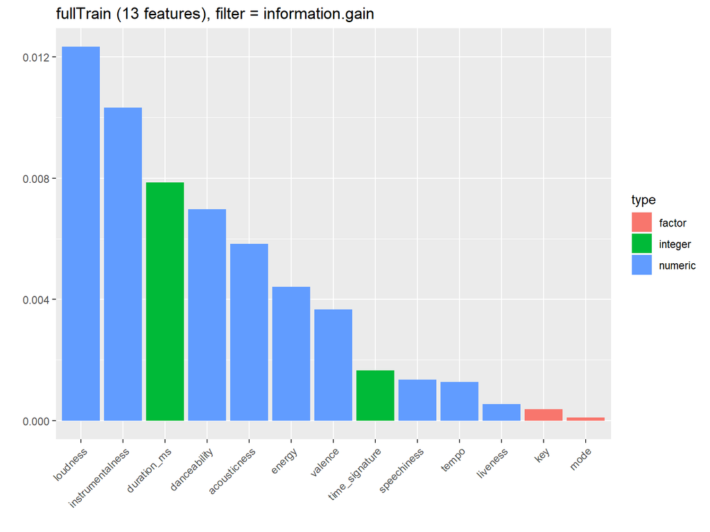

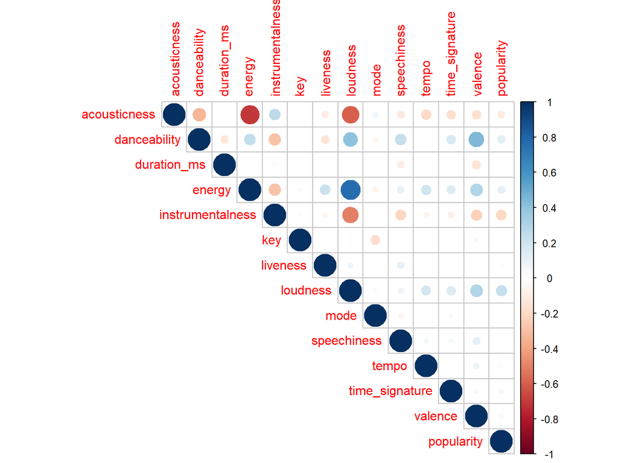

# How are the ‘Top’ features related to Popularity

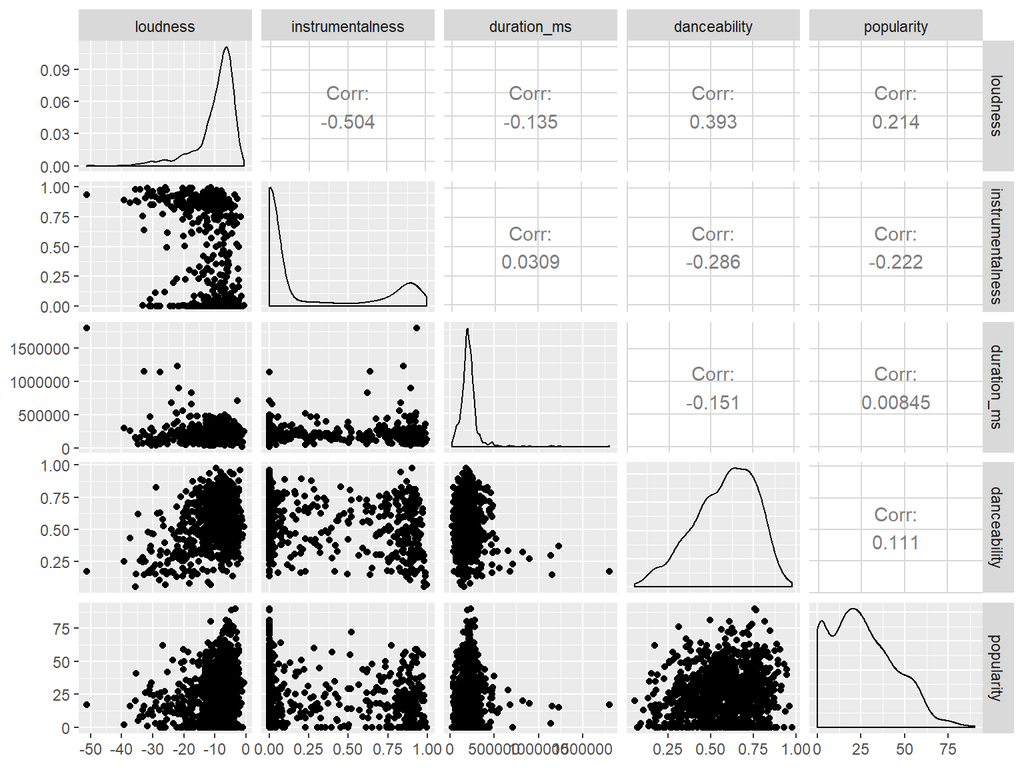

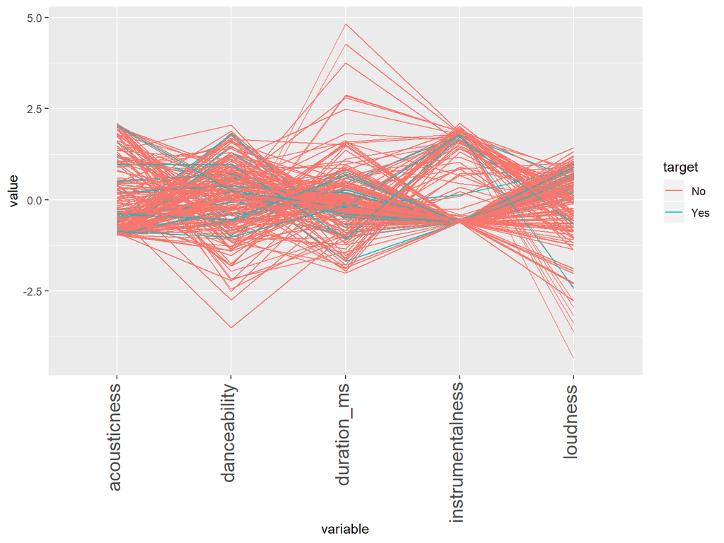

# Most Popular Songs of 2018

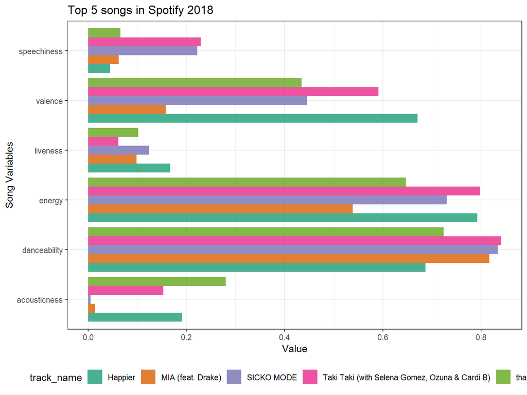

# Top 100 Songs by Key and Emotion

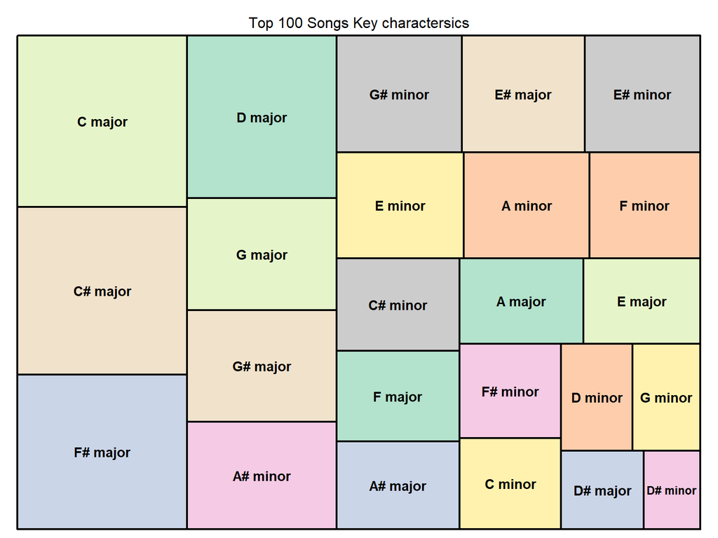

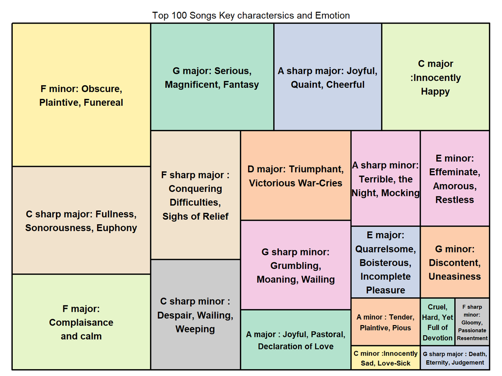

# How does mood affect the popularity of a song?

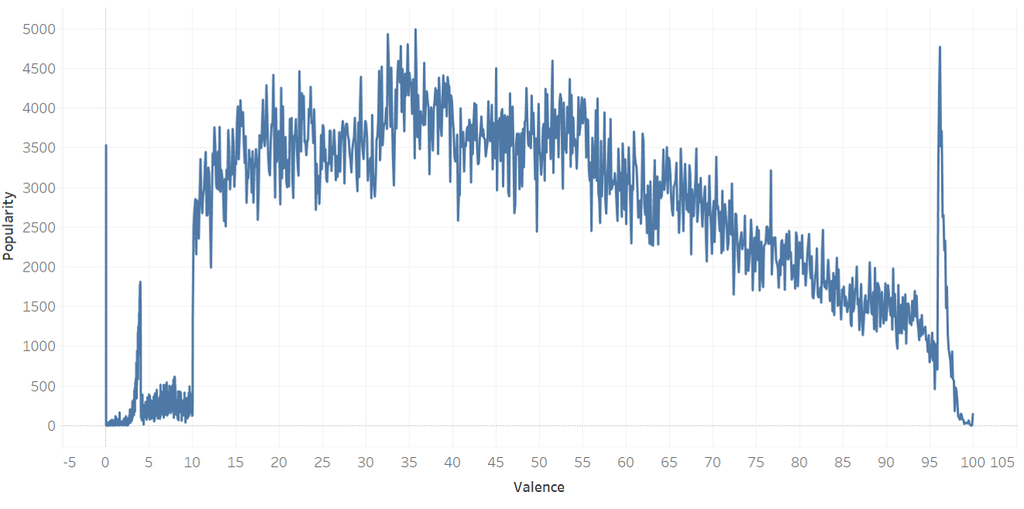

# Energy Vs. Popularity

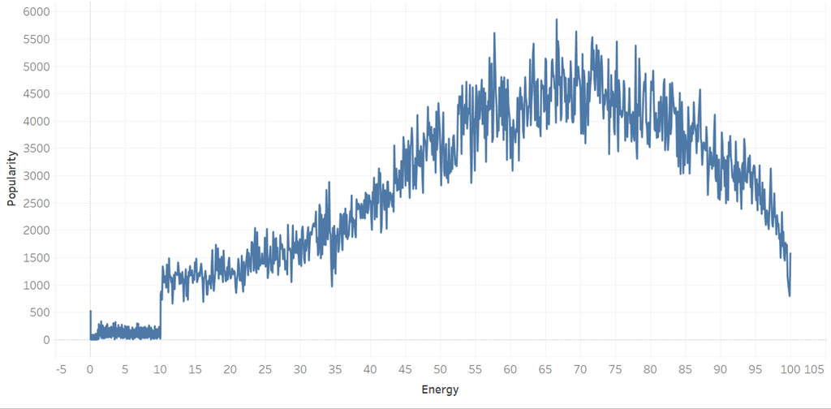

# Does the name of the song matter?

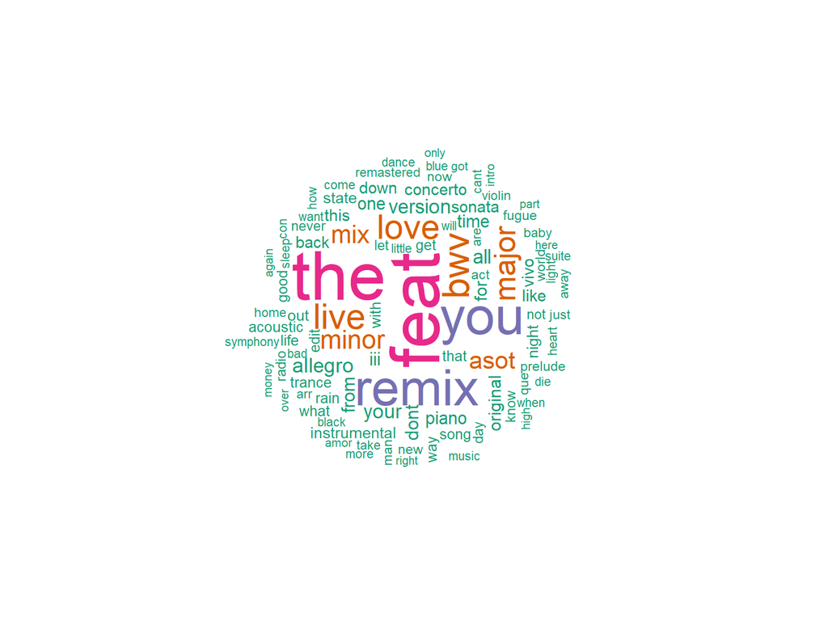

# Model Building and Evaluation

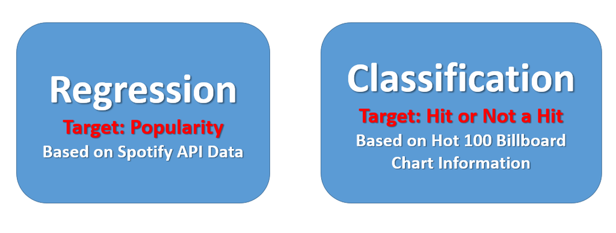

# The Regression Problem

Popularity is a copntinuous variable that ranges between 0 and 1

```
## [1] "Minimum Popularity is 0.1"
```

```
## [1] "Maximum Popularity is 0.9"
```

Models considered:  
- Model appropriate for the random component of the response variable; a **GLM with beta random component**.  
- A model that relaxes assumptions of linearity and probability distribution; a nonparametric model **Multivariate Adaptive Regression Splines**

### The Beta Distribution

Ferrari and Cribari-Neto, 2004 proposed a reparametrization of the **Beta Distribution** , $\mu=p/(p+q)$ and $\phi=p+q$, with the density function being:
$$f(y \mid \mu,\phi)=\frac{\Gamma(\phi)}{\Gamma(\mu\phi)\Gamma((1-\mu)\phi)}y^{\mu\phi-1}(1-y)^{(1-\mu)\phi-1}, \;\;\; \;\;0<y<1$$

$$E(y)=\mu$$
and
$$Var(y)=\frac{\mu(1-\mu)}{1+\phi}$$
The parameter $\phi$ is known as the precision parameter. Notice that for fixed $\mu$, $\phi$ gets larger and variance of $y$ gets smaller. The inverse of $\phi^{-1}$ is also known as the dispersion parameter.

This parameterization is particularly useful in linear regression since it involves modeling the mean or the expected value of the response variable$(y)$. Thus $\mu$ is the mean of the response variable.

# The Beta [GLM] Model

Following the latter parameterization of the beta distribution proposed by Ferrari and Cribari-Neto(2004) above, let $y_1, y_2, ...,y_n$ be a random sample such that $y_i \sim Beta(\mu_i,\phi)\;\;\;\;i=1,2,...,n$. Then the beta regression model is defined as:

$$g(\mu_i)=x_i^T\beta$$
where $\beta=(\beta_1, \beta_2,...,\beta_p)$ is a $p\times1$ vector of unknown parameters$(p<n), \;\;x_i=(x_{i1},(x_{i},...,(x_{ip})^T$ is the vector of $p$ regressors or the independent variables of this model. $x_i^T\beta=\eta_i$ is the linear predictor or the systematic component of the model.

Also note that the link function represented by $g(*):(0,1) \implies \mathbb{R}$ is strictly increasing in $*$ and twice differentiable hence continuous everywhere.

Due the the link, random (beta distribution) and systematic component (linear predictor), the beta regression model can be modelled seen as a Generalized Linear Model (GLM) (Agresti et al. Categroical Data Analysis). This offers flexibility in the choice of the link function to suit particular cases. Some common link functions are:

### Some Common Link functions

- **logit** $g(\mu) = log(\frac{\mu}{1-\mu})$, thus $\mu=\frac{e^{x_i^T\beta}}{1+e^{x_i^T\beta}}$
- **log-log** $g(\mu) = log(-log(\mu))$
- **Probit** $g(\mu) = \phi^{-1}(\mu)$
- **Complimentary log-log** $g(\mu) = log(-log(1-\mu))$
- **Cauchit** $g(\mu) = tan(\pi (\mu - 0.5))$
- **Identity** $g(\mu) = \mu$

Like with most GLM, the inverse function $\mu=g^{-1}(x_i^T\beta)$, is a function (linear combination) of the regression parameters $\beta$, hence the maximum likelihood estimation is adopted.

# The Classification Problem

This problem is a classic case of class imbalance with the class of interest being roughly 10 percent of available data.

```
##
##         No        Yes
## 0.90100712 0.09899288
```

A rather simple criteria was adopted. Fit models that:

1. produces the best prediction of classes, and with a variable selection feature
2. produces the best prediction, and with the best variable explanation

Models that meet criteria 1: Models that employ Gradient Boosting Algorithms OR Bagging Algorithms. Due to serious computational constraints only the **XGBoost, C5.0** models were considered with optimal parameter turning.

Models that meet criteria 2: Models that employ Stacking or Bagging algorithms. Here, only the **logistic regression and random forest models** were considered.

# Model Building - Beta Regression Model

- First conduct feature selection using the Recursive Feature Elimination (RFE) algorithm
- Cross-validate model accross a combination of its tuning parameters using selected variables from the RFE: **the link function**, **parameter estimation criteria**, and the **precision parameter**

### Recursive Feature Elimination

| Variables | RMSE | MAE | RMSESD | MAESD |
| --- | --- | --- | --- | --- |
| 4 | 0.111061758394933 | 0.08716393 | 0.00542281 | 0.00354431 |
| 8 | 0.108099836862348 | 0.08480530 | 0.00598517 | 0.00380319 |
| 13 | 0.107954511838087 | 0.08533066 | 0.00598095 | 0.00438428 |

|  | Overall |
| --- | --- |
| loudness | 31.7487433749014 |
| duration_ms | 22.882898370848 |
| acousticness | 22.2504527619254 |
| energy | 18.4672959489385 |
| valence | 17.99427522369 |
| instrumentalness | 15.353689685709 |
| danceability | 12.7056183121418 |
| liveness | 11.4294352638338 |
| speechiness | 9.30386751395376 |
| tempo | 5.141044846442 |
| time_signature | 4.16323447729347 |
| key | 3.49741110881659 |
| mode | 2.62180286702758 |

# The Beta Model

**Tuning Parameters of Beta Model**

```r
betamod
```

```
## 61966 samples
##    13 predictor
##
## Pre-processing: scaled (11), centered (11), ignore (2)
## Resampling: Cross-Validated (10 fold)
## Summary of sample sizes: 55770, 55768, 55770, 55771, 55771, 55769, ...
## Resampling results across tuning parameters:
##
##   link     type  link.phi  RMSE       Rsquared    MAE
##   cauchit  BC    identity  0.1456136  0.07953684  0.1181710
##   cauchit  BC    log       0.1456136  0.07953684  0.1181710
##   cauchit  BC    sqrt      0.1456136  0.07953684  0.1181710
##   cauchit  BR    identity  0.1456136  0.07953670  0.1181710
##   cauchit  BR    log       0.1456136  0.07953670  0.1181710
##   cauchit  BR    sqrt      0.1456136  0.07953670  0.1181710
##   cauchit  ML    identity  0.1456131  0.07953800  0.1181683
##   cauchit  ML    log       0.1456131  0.07953800  0.1181683
##   cauchit  ML    sqrt      0.1456131  0.07953800  0.1181683
##   cloglog  BC    identity  0.1459019  0.07625948  0.1185000
##   cloglog  BC    log       0.1459019  0.07625948  0.1185000
##   cloglog  BC    sqrt      0.1459019  0.07625948  0.1185000
##   cloglog  BR    identity  0.1459019  0.07625947  0.1185000
##   cloglog  BR    log       0.1459019  0.07625947  0.1185000
##   cloglog  BR    sqrt      0.1459019  0.07625947  0.1185000
##   cloglog  ML    identity  0.1459017  0.07625965  0.1184986
##   cloglog  ML    log       0.1459017  0.07625965  0.1184986
##   cloglog  ML    sqrt      0.1459017  0.07625965  0.1184986
##   log      BC    identity  0.1458171  0.07725545  0.1184169
##   log      BC    log       0.1458171  0.07725545  0.1184169
##   log      BC    sqrt      0.1458171  0.07725545  0.1184169
##   log      BR    identity  0.1458171  0.07725543  0.1184169
##   log      BR    log       0.1458171  0.07725543  0.1184169
##   log      BR    sqrt      0.1458171  0.07725543  0.1184169
##   log      ML    identity  0.1458168  0.07725567  0.1184150
##   log      ML    log       0.1458168  0.07725567  0.1184150
##   log      ML    sqrt      0.1458168  0.07725567  0.1184150
##   logit    BC    identity  0.1459821  0.07532498  0.1185772
##   logit    BC    log       0.1459821  0.07532498  0.1185772
##   logit    BC    sqrt      0.1459821  0.07532498  0.1185772
##   logit    BR    identity  0.1459821  0.07532498  0.1185772
```

[output cut: 12 more lines]

```
##   loglog   ML    log       0.1461812  0.07308532  0.1187739
##   loglog   ML    sqrt      0.1461812  0.07308532  0.1187739
##   probit   BC    identity  0.1460477  0.07459661  0.1186461
##   probit   BC    log       0.1460477  0.07459661  0.1186461
##   probit   BC    sqrt      0.1460477  0.07459661  0.1186461
##   probit   BR    identity  0.1460477  0.07459664  0.1186461
##   probit   BR    log       0.1460477  0.07459664  0.1186461
##   probit   BR    sqrt      0.1460477  0.07459664  0.1186461
##   probit   ML    identity  0.1460477  0.07459639  0.1186454
##   probit   ML    log       0.1460477  0.07459639  0.1186454
##   probit   ML    sqrt      0.1460477  0.07459639  0.1186454
##
## RMSE was used to select the optimal model using the smallest value.
## The final values used for the model were link = cauchit, type = ML
##  and link.phi = identity.
```

### Final model and Test Error

```r
betamod$finalModel
```

```
##
## Call:
## NULL
##
## Coefficients (mean model with cauchit link):
##      (Intercept)      acousticness      danceability       duration_ms
##       -0.6673101         0.0152467         0.0669982        -0.0354064
##           energy  instrumentalness              key1              key2
##       -0.0794817        -0.0506730        -0.0113945        -0.0319895
##             key3              key4              key5              key6
##       -0.0078742        -0.0047871        -0.0099531         0.0073453
##             key7              key8              key9             key10
##       -0.0205344         0.0028557        -0.0237952         0.0010925
##            key11          liveness          loudness             mode1
##        0.0064636        -0.0076288         0.2016049        -0.0207703
##      speechiness             tempo    time_signature           valence
##       -0.0206394         0.0007677         0.0107889        -0.0404638
##
## Phi coefficients (precision model with identity link):
## (phi)
## 9.835
```

```r
#varImp(betamod)
RMSE(TEST$popularity, predict(betamod, newdata = TEST))
```

```
## [1] 0.1451805
```

# MARS Model

- a piecewise linear model that captures the nonlinearity aspect of polynomial regression by assessing cutpoints (knots) similar to step functions.
  - Cross-validate to tune model complexity by pruning for an optimal combination of model hyperparameters
  - **Pruning Parameters**: **degree of interactions** and the **number of retained terms**

### 10-Fold Cross Validation

```r
MARS_model$finalModel
```

```
## Selected 22 of 29 terms, and 8 of 23 predictors
## Termination condition: RSq changed by less than 0.001 at 29 terms
## Importance: loudness, energy, instrumentalness, danceability, ...
## Number of terms at each degree of interaction: 1 9 6 6
## GCV 0.02064837    RSS 1277.288    GRSq 0.1025553    RSq 0.1040753
```

```r
# best model
MARS_model$bestTune
```

```
##    nprune degree
## 24     34      3
```

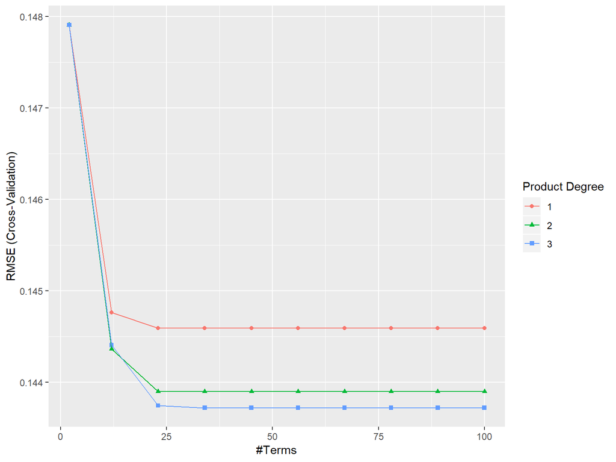

```r
# plot results
ggplot(MARS_model)
```

# MARS Model Analysis

|  | x |
| --- | --- |
| (Intercept) | 0.15680566 |
| h(loudness- -1.68027) | 0.06852939 |
| h(-1.68027-loudness) | 0.08147378 |
| h(energy-1.05261) | -0.04327685 |
| h(1.05261-energy) | 0.03033633 |
| h(instrumentalness- -0.228467) * h(loudness- -1.68027) | -0.01300844 |
| h(-0.228467-instrumentalness) * h(loudness- -1.68027) | 0.05957354 |
| h(danceability- -1.87325) | 0.00891184 |
| h(valence-0.986294) | -0.03828531 |
| h(0.986294-valence) | 0.00535404 |
| h(2.1367-instrumentalness) | -0.01678996 |
| h(1.05261-energy) * h(-1.22029-loudness) | -0.02722080 |
| h(-0.228467-instrumentalness) * h(loudness- -1.68027) * h(speechiness- -0.487573) | -0.01411068 |
| h(duration_ms-3.9199) | 0.01185932 |
| h(duration_ms- -0.244934) * h(-0.228467-instrumentalness) * h(loudness- -1.68027) | -0.01207732 |
| h(-0.244934-duration_ms) * h(-0.228467-instrumentalness) * h(loudness- -1.68027) | -0.08844306 |
| h(acousticness- -0.936029) * h(0.986294-valence) | 0.00557207 |
| h(-0.936029-acousticness) * h(0.986294-valence) | -0.38960972 |
| h(1.05261-energy) * h(loudness- -1.22029) * h(-0.179575-speechiness) | -0.02979594 |
| h(acousticness- -0.936029) * h(duration_ms- -0.125109) * h(0.986294-valence) | -0.00270132 |
| h(acousticness- -0.936029) * h(-0.125109-duration_ms) * h(0.986294-valence) | -0.00505529 |
| h(danceability- -1.87325) * h(0.435338-duration_ms) | 0.01141341 |

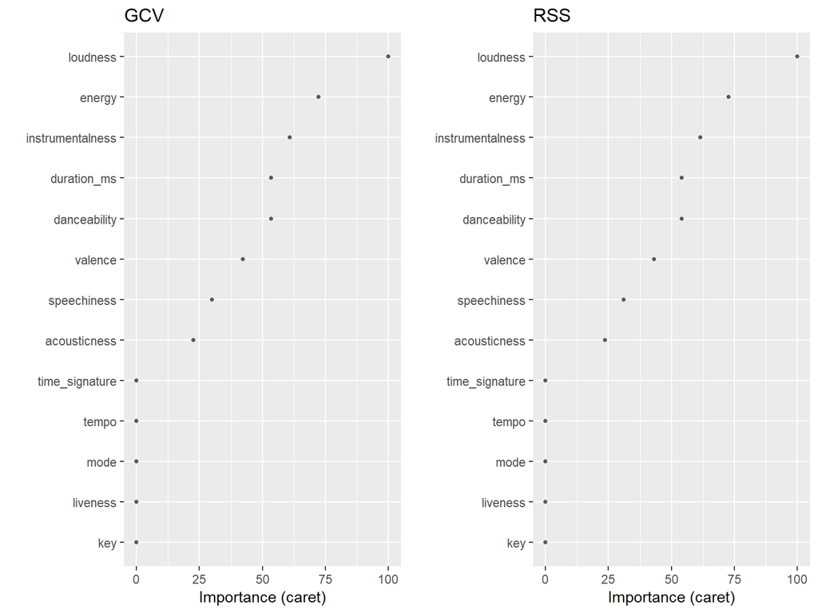

### Test Set Diagnostics

```r
RMSE(TEST$popularity, predict(MARS_model, newdata = TEST))
```

```
## [1] 0.1435355
```

# The Imbalanced Classification Challenge

Four sampling schemes were adopted - Weighted, Under, Over and SMOTE (Synthetic Minority Over-sampling Technique).

Below is the outline of the simple strategy:

### Tuning the Extreme Gradient Machine

[figure not shown]

```r
gg1 <- tuneplot(xgb_tune) + ggtitle('1. Number of Iterations and Learning Rate')+
  scale_fill_continuous(guide = guide_legend()) +
    theme(legend.position="bottom")

gg2 <- tuneplot(xgb_tune2) + ggtitle('2. Maximum Depth and Minimum Child Weight')+
  scale_fill_continuous(guide = guide_legend()) +
    theme(legend.position="bottom")
gg3 <- tuneplot(xgb_tune3) + ggtitle('3. Column and Row Sampling')+
  scale_fill_continuous(guide = guide_legend()) +
    theme(legend.position="bottom")
gg4 <- tuneplot(xgb_tune4) + ggtitle('4. Tuning Gamma')+
  scale_fill_continuous(guide = guide_legend()) +
    theme(legend.position="bottom")
gg5 <- tuneplot(xgb_tune5) + ggtitle('5. Reducing the Learning Rate')

grid.arrange(gg1, gg2, ncol=2)
```

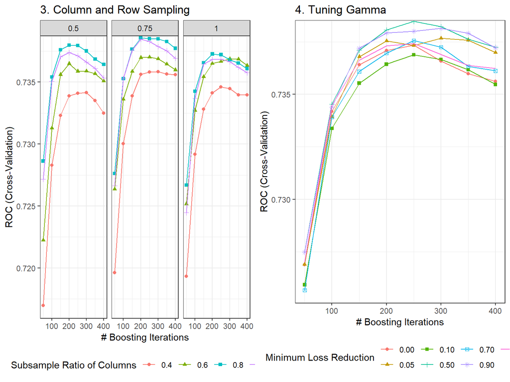

```r
grid.arrange(gg3, gg4, ncol=2)
```

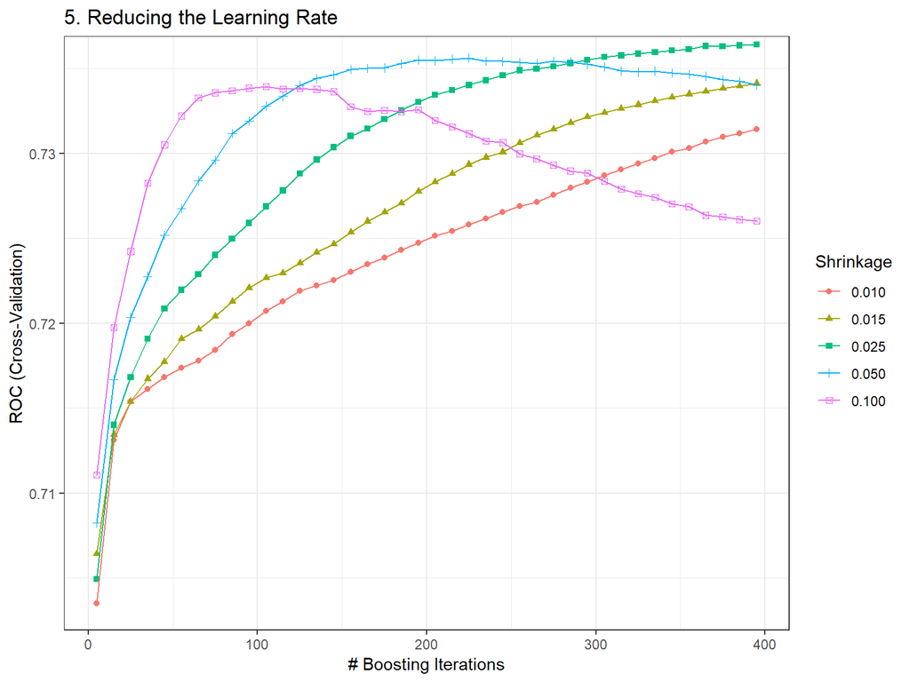

```r
gg5
```

# Final Models

### The XGBoost Models

```r
xgb_smote.model
```

```
## ##### xgb.Booster
## Handle is invalid! Suggest using xgb.Booster.complete
## raw: 348.8 Kb
## call:
##   xgb.train(params = parameters, data = train_smote_xgb, nrounds = 100,
##     watchlist = watchlist)
## params (as set within xgb.train):
##   booster = "gbtree", silent = "0", eta = "0.3", gamma = "0", max_depth = "6", min_child_weight = "1", subsample = "1", colsample_bytree = "1", colsample_bylevel = "1", lambda = "1", alpha = "0", objective = "binary:logistic", eval_metric = "auc", seed = "1900", silent = "1"
## callbacks:
##   cb.print.evaluation(period = print_every_n)
##   cb.evaluation.log()
## # of features: 13
## niter: 100
## nfeatures : 13
## evaluation_log:
##     iter train_auc   cv_auc
##        1  0.652987 0.644992
##        2  0.671370 0.662983
## ---
##       99  0.769290 0.697368
##      100  0.769582 0.697287
```

```r
xgb_final$bestTune
```

```
##   nrounds max_depth  eta gamma colsample_bytree min_child_weight subsample
## 1     325         6 0.05  0.05              0.8                2         1
```

```r
varImp(xgb_final)
```

```
## xgbTree variable importance
##
##                    Overall
## loudness         100.00000
## instrumentalness  45.72585
## duration_ms       41.56472
## energy            39.34733
## danceability      36.90747
## valence           29.36691
## acousticness      28.35109
## speechiness       26.34988
## tempo             25.19179
## liveness          16.96537
## key                3.57600
## time_signature     0.01203
## mode               0.00000
```

### The Random Forest Models

```r
models_roc %>% map(auc)
```

```
## $original
## Area under the curve: 0.6801
##
## $weighted
## Area under the curve: 0.7436
##
## $down
## Area under the curve: 0.7437
##
## $up
## Area under the curve: 0.7443
##
## $SMOTE
## Area under the curve: 0.7522
```

### The XGBoost Models

```r
XGB_list_roc %>%map(auc)
```

```
## $default
## Area under the curve: 0.7359
##
## $SMOTE
## Area under the curve: 0.7369
```

```r
xgb_smote.model$evaluation_log
```

```
##      iter train_auc   cv_auc
##   1:    1  0.652987 0.644992
##   2:    2  0.671370 0.662983
##   3:    3  0.678217 0.669416
##   4:    4  0.687700 0.675465
##   5:    5  0.697000 0.682796
##   6:    6  0.695479 0.680413
##   7:    7  0.698682 0.684284
##   8:    8  0.701076 0.684600
##   9:    9  0.705760 0.687224
##  10:   10  0.706900 0.686728
##  11:   11  0.709011 0.688928
##  12:   12  0.711427 0.691429
##  13:   13  0.712009 0.690576
##  14:   14  0.713169 0.691743
```

[output cut: 87 more lines]

```r
xgb_finalOther$bestTune
```

```
##   nrounds max_depth  eta gamma colsample_bytree min_child_weight subsample
## 1     325         6 0.05  0.05              0.8                2         1
```

```r
varImp(xgb_finalOther)
```

```
## xgbTree variable importance
##
##                   Overall
## loudness         100.0000
## instrumentalness  48.3927
## duration_ms       42.7876
## danceability      39.2607
## energy            39.0166
## acousticness      28.9588
## valence           28.4389
## speechiness       27.3646
## tempo             25.9785
## liveness          16.1048
## key                3.5266
## mode               0.2027
## time_signature     0.0000
```